# R Notebook

## Práctico 2

Usando *ggplot2*, vamos a seguir jugando con gapminder. Esta vez, vamos a explorar la relación entre la tasa de fertilidad, la expectativa de vida y el tamaño de la población.

```r
library(ggplot2)
library(tidyverse)

df <- read_csv("./data/clean_gapminder.csv")
```

## Ejercicio 1

Realizá un gráfico que muestre la relación entre la tasa de fertilidad y la expectativa de vida en el año 2007 para todos los países.

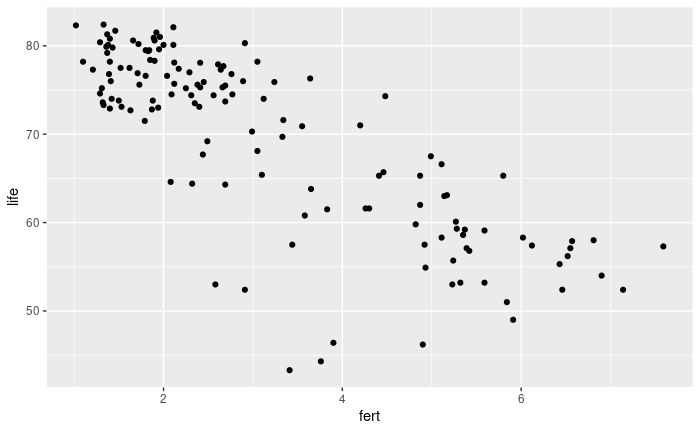

```r
#Puedo guardar los gráficos de ggplot en un objeto

g1 <- ggplot(df %>% filter(year == 2007), aes(x = fert, y = life))+
  geom_point()

g1
```

## Ejercicio 2

Introducí en el gráfico las variables de `continent` y `pop` (tamaño de la población). Pensá: ¿qué atributos estéticos puedo utilizar para mostrar los valores según el tipo de variable? Luego ploteá un gráfico de muestra.

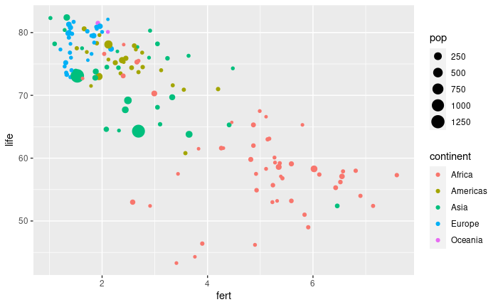

```r
g2 <- ggplot(df %>% filter(year ==2007), aes(x = fert, y = life, size = pop, color = continent))+
  geom_point()

g2
```

## Ejercicio 3

Modificá manualmente los colores de los continentes. Queremos que Europa tenga el tono “darkorange”, Asia “red”, África “blue”, las Américas “yellow” y Oceanía “purple”.

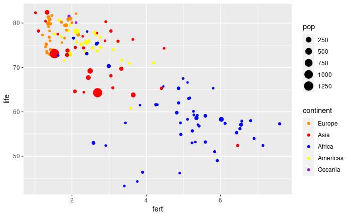

```r
vec_colores <- c("Europe" = "darkorange", "Asia" = "red", "Africa" = "blue", "Americas" = "yellow", "Oceania" = "purple")

g3 <- g2 +
  scale_color_manual(values = vec_colores)

g3
```

¿Y si quisiera mostrar dónde están Arg y Brasil en este gráfico?

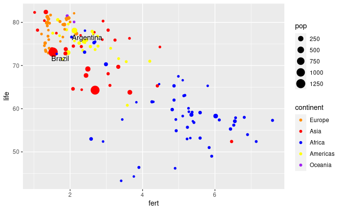

```r
library(ggrepel)

df07 <- df %>% filter(year == 2007)

g2 +
  geom_text_repel(data = df07 %>%filter(country == "Brazil" | country == "Argentina"),
                  aes(x = fert, y = life, label = country), inherit.aes = FALSE)+
  scale_color_manual(values = vec_colores)
```

## Ejercicio 4

Realizá limpieza y ordenamiento finales, asegurate de que las labels describan debidamente su elemento asignado.

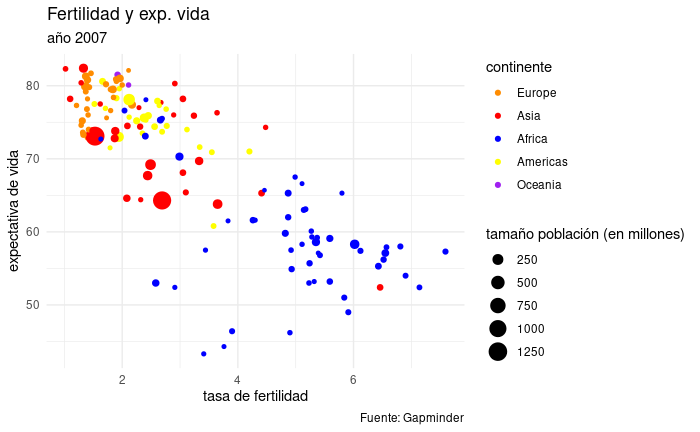

```r
g3 +
  labs(title = "Fertilidad y exp. vida",
       subtitle = "año 2007",
       size = "tamaño población (en millones)",
       color = "continente",
       y = "expectativa de vida",
       x = "tasa de fertilidad",
       caption = "Fuente: Gapminder")+
  theme_minimal()
```

¿Cómo guardo los gráficos? Uso `ggsave()` .

```r
ggsave('./plot_gapminder.png',
  width = 7,
  height = 3)
```

Recuerden que por default me guarda el último plot hecho, si lo quiero cambiar, modifico el parámetro `plot`. PERO para eso tengo que haberlo guardado en un objeto primero.